# Project: Multifactors Risk Research of China Stock Listed Banks

## 1. Problem Description & Goal

**Weighted Average Cost of Capital (WACC)** is probably the most important financial indicator to assess the load of a company to raise capital. It means the average rate of return a company is expected to pay its investors (both equity holders and debt holders) for using their capital. It reflects the company’s cost of financing its assets, weighted by the proportion of equity and debt in its capital structure. The formula is:

$$ r_{waac} = \frac{E}{E + D} \times r_e + \frac{D}{E + D} \times r_d \times (1 - t) $$

Where:

- $E$: Company's market value of equity
- $D$: Company's market value of debt
- $r_e$: Company's cost rate of equity, i.e. rate of return a company is expected to pay its equity holders
- $r_d$: Company's cost rate of debt, i.e. rate of return a company is expected to pay its debt holders
- $t$: Corporate tax rate

Furthermore, the risky part (**risk premium**) of WAAC means the risky load a company afford in order to raise capital with an expected average rate of return that exceed market interest rates, as defined:

$$ r_{waac}^* = r_{waac} - r_f $$

Where $r_f$: Market risk-free interest rate, often replaced by a proxy: Shanghai Interbank Offered Rate (SHIBOR)

**This project aims to explore how the risks hidden in different financial factors impact the risk of Chinese bank industry to raise capital, namely different financial factors' causal effects on the $r_{waac}^*$.**

## 2. Dataset Description

### 2.1 Define Modeler Class for Data Cleaning

```python
import random
import pickle
import pandas as pd
import numpy as np
import seaborn as sns
import matplotlib.pyplot as plt
from tqdm import tqdm
from sklearn.experimental import enable_iterative_imputer
from sklearn.impute import IterativeImputer
import xgboost as xgb
import script.datacamp_common_function as dcf

class Modeler():

    def __init__(
        self,
        mode='train',
        factors_datas_names=[
            'factors_data',
            'fundamentals_data',
            'macros_data',
            'money_flows_data',
            'securities_margins_data',
            'industries_data',
            'indexes_data'
            ],
        other_datas_names=[
            'bank_stocks_info',
            'returns_data',
            'FCF_discounted_model_params_data'
            ],
        random_state=20241020
        ):
        self.mode = mode
        self.random_state = random_state
        # Define all data other than factors datas as class attributes
        for other_data_name in other_datas_names:
            other_data = pickle.load(open(f'data/exported_data/{other_data_name}_{mode}.pkl', mode='rb+'))
            if other_data_name == 'bank_stocks_info':
                self.industry_stocks_info = other_data
            elif other_data_name == 'returns_data':
                self.returns_data = other_data
            elif other_data_name == 'FCF_discounted_model_params_data':
                self.FCF_discounted_model_params_data = other_data

        self.index = self.FCF_discounted_model_params_data['r_wacc'].index
        self.columns = self.FCF_discounted_model_params_data['r_wacc'].columns

        # Merge multiple factor data tables
        factors_datas = {}
        # Import data
        for factors_data_category in factors_datas_names:
            factors_data = pickle.load(open(f'data/exported_data/{factors_data_category}_{mode}.pkl', mode='rb+'))
            factors_datas[factors_data_category] = factors_data

        self.factors_datas = factors_datas
        pickle.dump(obj=factors_datas, file=open(file=f'data/modeled_data/factors_datas_{self.mode}.pkl', mode='wb+'), protocol=4)

    # Check whether each factor is an empty table
    def check_factor_data_nan(self):
        factor_data_nan_dict = {}
        for factors_data_category, factors_data in tqdm(self.factors_datas.items(), desc='handling factors datas missing values progress'):
            factor_data_nan_dict[factors_data_category] = []
            for factor_data_code, factor_data in factors_data.items():
                if not factor_data.any().any():
                    factor_data_nan_dict[factors_data_category].append(factor_data_code)

        return factor_data_nan_dict


    # Define standardized factor risk classification data table
    def standardize_factors_risks_data(self):
        # Import the manually divided factor risk classification data table factors risks data, which has three columns, including the Chinese name of the factor, the factor code and the risk that the factor belongs to
        factors_risks_data = pd.read_csv('data/dict/factors_risks_data.csv')

        # Check the factors risks data for missing factor codes
        factors_codes_missing = []
        for _, factors_data in self.factors_datas.items():
            for factor_data_code in factors_data.keys():
                if factor_data_code not in factors_risks_data['factor_code'].values:
                    factors_codes_missing.append(factor_data_code)

        # Check the factors risks data for duplicate factor codes

        # Define factor codes list
        factors_codes = []
        for factors_data in self.factors_datas.values():
            factors_codes.append(list(factors_data.keys))

        # Define function to find duplicates in a given list
        def find_duplicates(lst):
            duplicates = []
            unique_elements = set()

            for item in lst:
                if item in unique_elements:
                    duplicates.append(item)
                else:
                    unique_elements.add(item)

            return duplicates

        # Find duplicates in the factor codes list
        factors_codes_duplicated = find_duplicates(factors_codes)

        # Check the factors risks data for redundant factor codes
        factors_codes_excessive = []
        for factor_code in factors_risks_data['factor_code'].values:
            if factor_code not in factors_codes:
                factors_codes_excessive.append(factor_code)

        # Unify the risk column in factors_risks_data to 3 dummy variables which display whether the factor belongs to the particular risk
        factors_risks_data = factors_risks_data.set_index('factor_code')
        factors_risks_data_standardized = pd.DataFrame(0, columns=['default_risk', 'liquidity_risk', 'market_risk'], index=factors_risks_data.index)
        for factor_code in factors_risks_data.index.tolist():
            if 'Default Risk' in factors_risks_data.loc[factor_code, 'risk']:
                factors_risks_data_standardized.loc[factor_code, 'default_risk'] = 1
            if 'Liquidity Risk' in factors_risks_data.loc[factor_code, 'risk']:
                factors_risks_data_standardized.loc[factor_code, 'liquidity_risk'] = 1
            if 'Market Risk' in factors_risks_data.loc[factor_code, 'risk']:
                factors_risks_data_standardized.loc[factor_code, 'market_risk'] = 1

        self.factors_risks_data_standardized = factors_risks_data_standardized

        return factors_codes_missing, factors_codes_excessive, factors_codes_duplicated, factors_risks_data_standardized

    def _fill_nan_col(self, factor_data_without_type1_missing, factor_data):
        # Find the column names (factor codes) with all data missing (type2_missing) in factor_data_without_type1_missing
        missing_stocks_codes = factor_data_without_type1_missing.columns[factor_data_without_type1_missing.isnull().all()]
        # Calculate ranks for each rows of the columns within each rows of factor_data as a data table with index as column names
        missing_stocks_codes_quantiles = factor_data.rank(pct=True, axis=1)[missing_stocks_codes]
        # Calculate the mean rank of ranks for each rows of the columns as a series with index as column names
        missing_stocks_codes_quantiles_mean = missing_stocks_codes_quantiles.mean()
        # Covert the mean rank series to the corresponding mean quantile series within factor_data_without_type1_missing with index as column names
        fill_values = factor_data_without_type1_missing.quantile(missing_stocks_codes_quantiles_mean, axis=1)
```

```python
        # Compatible fill_values and factor_data_without_type1_missing
        fill_values = fill_values.T
        fill_values.columns = missing_stocks_codes

        # Fill the columns' type2 missing values with the mean quantile series
        factor_data_without_type1_missing.update(fill_values) # Do not assign df to df, the former should take .values and become np.array, but it will still warn, so update is used
        return factor_data_without_type1_missing

    # Handle missing values
    def _handle_missing_values(self, factor_data):
        '''
        Some factor values in factor_data are missing. These missing values are either due to stocks not having factor values before listing or after delisting, or because factor values were not disclosed or recorded during the trading period. When handling missing values, the missing values Ⅰ should be ignored, while the second type should be filled.
        There are generally three methods for filling missing values: SimpleImputation, KNNImputation, and IterativeImputation.
        For this panel data, SimpleImputation (such as mean or median filling) may not be suitable because it does not consider the time series characteristics and the correlation between stocks. Simply filling missing values with a constant may introduce bias, especially when the proportion of missing values is high.
        KNNImputation can consider the correlation between stocks, but it does not take into account the time series characteristics either. In addition, KNNImputation may be relatively slow when dealing with large-scale panel data because it requires calculating the distance matrix between all stocks. Therefore, IterativeImputer should be chosen. Its advantages and disadvantages include considering the time series characteristics and the correlation between stocks.
        However, using IterativeImputer to fill all missing values and then removing the missing values Ⅰ may not be the best approach. This is because IterativeImputer considers all features, including those that should not exist and are to be filled (the missing values Ⅰ), when estimating missing values. This may affect the quality of the estimates.
        Therefore, the following approach is a better choice. First, identify the sample dates (index) that do not contain the missing values Ⅰ (all stocks are listed) and use only these samples to train the IterativeImputer. Then, use the trained IterativeImputer to estimate the missing values Ⅱ in all samples. It is worth noting that some columns of these samples only contain missing values (the missing values Ⅱ), and such samples cannot be used for training. We first obtain the average rank of each row in the entire data factor_data, then take the quantile corresponding to this rank in factor_data_without_type1_missing to fill the missing value column.
        '''
        # Define a mask to indicate whether each stock is listed at each time point
        mask = pd.DataFrame(index=self.index, columns=self.columns)
        # Get the median for each row (axis=1) of the factor data table to form a median vector for each cross-section
        medians = factor_data.median(axis=1)
        # For each stock code
        for stock_code in mask.columns:
            # For the stock with code stock_code, find its corresponding listing date start_date and delisting date end_date from the industry stocks information
            start_date = self.industry_stocks_info.loc[stock_code, 'start_date']
            end_date = self.industry_stocks_info.loc[stock_code, 'end_date']
            # Indicate whether the stock with code stock_code is listed at each time point
            mask[stock_code] = (mask.index >= start_date) & (mask.index <= end_date)

            # For the stock with code stock_code, if its factor values factor_data[stock_code] are all missing (np.nan) at all times
            if factor_data[stock_code].isnull().all():
                # Set the factor values for stock_code at all times to the median vector to prevent being ignored by the Imputer
                medians = pd.DataFrame(medians)
                medians.columns = [stock_code]
                factor_data.update(medians)

        # Based on the mask, get the date index that does not contain the missing values Ⅰ (not listed)
        indexes_without_type1_missing = mask.all(axis=1)
        # Define the factor data sample corresponding to the date index without the missing values Ⅰ
        factor_data_without_type1_missing = factor_data.loc[indexes_without_type1_missing]

        # For the columns in factor_data_without_type1_missing that are all missing values, obtain their average rank in the entire data factor_data,
        # and take the corresponding quantile in factor_data_without_type1_missing to fill the missing value column
        factor_data_without_type1_missing = self._fill_nan_col(factor_data_without_type1_missing, factor_data)

        # Define the IterativeImputer, which needs to be retrained after filling all missing values and then re-fill the original missing values until convergence,
        # with a maximum iteration count max_iter of 50 and a random seed random_state of self.random_state
        imputer = IterativeImputer(
            random_state=self.random_state,
            # Use IsolationXFBoost to fill missing values
            estimator=xgb.XGBRegressor(),
            max_iter=50,
            tol=1e-3
        )

        # Train the IterativeImputer using factor_data_without_type1_missing
        imputer.fit(factor_data_without_type1_missing)
        # Use the imputer to fill all missing values in factor_data, resulting in the filled factor data table factor_data_imputed
        factor_data_imputed = imputer.transform(factor_data)
        factor_data_imputed = pd.DataFrame(factor_data_imputed)
        factor_data_imputed.index = self.index
        factor_data_imputed.columns = self.columns

        # Re-label the missing values Ⅰ in the filled factor data table factor_data_imputed back to np.nan,
        # that is, use the trained imputer to estimate all missing values Ⅱ in the factor data table
        factor_data_imputed[~mask] = np.nan
```

```python
        return factor_data_imputed

    # Fama-French-3分位数差值处理
    def _process_ff3_quantile_difference(self, factor_data):
        '''
        FF3 deals with forming cross-sectional stock return yield:
        Reasonability: If your research goal is to investigate the factor's cross-sectional predictive ability for stock return yield and assume that the cross-sectional distribution of stock return yield is related to the factor's cross-sectional distribution, then processing the cross-sectional stock return yield according to FF3 is appropriate.
        Advantages: This method can eliminate the extreme impact of stock return yield, making the distribution of cross-sectional stock return yield more stable, which is convenient for studying the predictive ability of the factor.
        Disadvantages: This method ignores the impact of enterprise value on stock return yield, and may not reflect the overall yield change in the market.
        '''
        panal_factor_data_quantiles = factor_data.quantile([0.3, 0.7], axis=1)
        panal_factor_data = panal_factor_data_quantiles.loc[0.7] - panal_factor_data_quantiles.loc[0.3]
        return panal_factor_data

    # Enterprise value weighting
    def _average_by_enterprise_value(self, factor_data):
        '''
        Form a enterprise value weighted sectoral factors data table:
        Reasonableness: If your research goal is to investigate the predictive power of factors on the overall market return, and you assume that the enterprise value of individual stocks reflects their importance in the market, then weighting the sectoral factors by enterprise value is appropriate.
        Advantages: This method takes into account the impact of enterprise value and reflects the overall change in market return, which is closer to the actual return of an investment portfolio.
        Disadvantages: This method may be dominated by large-cap stocks, and the impact of small-cap stocks may be obscured.
        For the research purpose of the bank sector in this paper, the weighted sectoral factors by enterprise value is chosen.
        '''
        weighted_factor_data = self.enterprise_value_weights * factor_data
        panal_factor_data = weighted_factor_data.sum(axis=1)

        panal_factor_data = pd.DataFrame(panal_factor_data)
        panal_factor_data.index = self.index
        #panal_factor_data.columns = [factor_data_code] # Do not reset column names to prevent missing values from appearing when comparing with other panal_factor_data calculations due to inconsistent column names
        return panal_factor_data

    # Missing value processing and Enterprise value weighting
    def clean_and_average_factors_datas(self):
        self.enterprise_value_weights = self.FCF_discounted_model_params_data['panal_enterprise_value_weights']
        industry_factors_df = pd.DataFrame()

        for factors_data_category, factors_data in self.factors_datas.items():
            for factor_data_code, factor_data in tqdm(factors_data.items(), desc='handling factors data progress'):
                if factors_data_category != 'macros_data': #factor_data_code == 'PEG':
                    # Missing value processing
                    factor_data_imputed = self._handle_missing_values(factor_data)

                    # Enterprise value weighting
                    industry_factor_data = self._average_by_enterprise_value(factor_data_imputed)
                    # The r_wacc weighted by enterprise_value is obtained by summating the r_waac weighted by enterprise_value.
                    # Find r_E weighted by circulating_value and r_D weighted by Debts, respectively. Then r_E and r_D are weighted by the ratio of total circulating_value to the total enterprise_value and total Debts to the total enterprise_value of the section to get the r_wacc weighted by enterprise_value.
                    # These two processes are equivalent
                    industry_factors_df[factor_data_code] = industry_factor_data

        industry_factors_df.index = self.index
        self.industry_factors_df = industry_factors_df
        return industry_factors_df

    def clean_and_average_r_waac_data(self):
        self.enterprise_value_weights = self.FCF_discounted_model_params_data['panal_enterprise_value_weights']
        r_waac = self.FCF_discounted_model_params_data['r_wacc']
        industry_r_waac_df = pd.DataFrame()

        r_waac_imputed = self._handle_missing_values(r_waac)

        industry_r_waac = self._average_by_enterprise_value(r_waac_imputed)

        industry_r_waac_df['r_waac'] = industry_r_waac

        industry_r_waac_df.index = self.index

        self.industry_r_waac_df = industry_r_waac_df

        return industry_r_waac_df
```

### 2.2 Instantiate the Modeler

The modeler imports data as DataFrames from pickles and align them into `Modeler.factors_datas`.

```python
#from Modeler import Modeler

mode = input('Dataset is for train or test?')
mol = Modeler(mode)
```

### 2.3 Explore Original Data Structure

The `Modeler.factors_datas` includes 7 categories of financial factors (factors) about all listed banks in China, as the names shown:

```python
mol.factors_datas.keys()
```

```
dict_keys(['factors_data', 'fundamentals_data', 'macros_data', 'money_flows_data', 'securities_margins_data', 'industries_data', 'indexes_data'])
```

Each category dict include many factors data table, take the category `'factors_data'` for example:

```python
mol.factors_datas['factors_data'].keys()
```

```
dict_keys(['administration_expense_ttm', 'asset_impairment_loss_ttm', 'cash_flow_to_price_ratio', 'EBIT', 'EBITDA', 'financial_assets', 'interest_free_current_liability', 'market_cap', 'net_debt', 'net_finance_cash_flow_ttm', 'net_interest_expense', 'net_invest_cash_flow_ttm', 'net_operate_cash_flow…
```

Each indicator data table display the

> - **not imputed** (missing values contained)
> - **tail-shrinked** (outlies processed, see[1])
> - **standardized**
> - **industry-neutralized** and **circulating market capitalization-neutralized** (residualized, see[2]) \

[1]: Treat the values ouside $[\operatorname{median} - 5\operatorname{IQR}, \operatorname{median} + 5\operatorname{IQR}]$ as outliers and replace them with the boundary value they hit. The oulier processing is conservative because the outliers are collected in a formal statistical process which preserves its reality.  
[2]: $\operatorname{factor}_i = \beta_0 + \beta_1 \operatorname{industry}_i + \beta_2 \operatorname{market \space capitalization}_i + \epsilon_i$ where $i$ denotes the ordinal number of the bank and $\operatorname{industry}_i := \mathbb{I}(\text{bank}_i \space \text{is in the industry})$. The $\epsilon_i$, as the residualized $\operatorname{factor}_i$ is called neturalized $\operatorname{factor}_i$ which is orthogonalized to $\operatorname{industry}_i$ and $\operatorname{market \space capitalization}_i$.

Take a indicator `'administration_expense_ttm'` form category `'factors_data'` for example:

```python
mol.factors_datas['factors_data']['administration_expense_ttm']
```

| code date | 600928.XSHG | 600016.XSHG | 002807.XSHE | 600926.XSHG | 601658.XSHG | 002142.XSHE | 601229.XSHG | 002966.XSHE | 600000.XSHG | 002936.XSHE | ... | 603323.XSHG | 601328.XSHG | 601398.XSHG | 601528.XSHG | 601838.XSHG | 601988.XSHG | 601825.XSHG | 601997.XSHG | 601128.XSHG | 600015.XSHG |
| --- | --- | --- | --- | --- | --- | --- | --- | --- | --- | --- | --- | --- | --- | --- | --- | --- | --- | --- | --- | --- | --- |
| 2019-01-02 | NaN | -0.192939 | -0.153628 | -0.003386 | NaN | 0.184528 | 0.147090 | NaN | -0.364477 | -0.073653 | ... | -0.151028 | 0.473023 | 0.625446 | NaN | -0.082815 | 0.625446 | NaN | -0.055402 | -0.113116 | -1.167848 |
| 2019-01-03 | NaN | -0.019341 | -0.163877 | 0.007466 | NaN | 0.221772 | 0.179076 | NaN | -0.214971 | -0.072671 | ... | -0.160913 | 0.450172 | 0.450172 | NaN | -0.083119 | 0.450172 | NaN | -0.051856 | -0.117675 | -1.131176 |
| 2019-01-04 | NaN | -0.019341 | -0.163877 | 0.007466 | NaN | 0.221772 | 0.179076 | NaN | -0.214971 | -0.072671 | ... | -0.160913 | 0.450172 | 0.450172 | NaN | -0.083119 | 0.450172 | NaN | -0.051856 | -0.117675 | -1.131176 |
| 2019-01-07 | NaN | -0.019341 | -0.163877 | 0.007466 | NaN | 0.221772 | 0.179076 | NaN | -0.214971 | -0.072671 | ... | -0.160913 | 0.450172 | 0.450172 | NaN | -0.083119 | 0.450172 | NaN | -0.051856 | -0.117675 | -1.131176 |
| 2019-01-08 | NaN | -0.019341 | -0.163877 | 0.007466 | NaN | 0.221772 | 0.179076 | NaN | -0.214971 | -0.072671 | ... | -0.160913 | 0.450172 | 0.450172 | NaN | -0.083119 | 0.450172 | NaN | -0.051856 | -0.117675 | -1.131176 |
| ... | ... | ... | ... | ... | ... | ... | ... | ... | ... | ... | ... | ... | ... | ... | ... | ... | ... | ... | ... | ... | ... |
| 2022-12-26 | -0.2165 | 0.183639 | -0.250547 | 0.159265 | 0.183639 | 0.807242 | 0.327506 | -0.11693 | 0.183639 | -0.137717 | ... | -0.246006 | 0.183639 | 0.183639 | -0.25452 | -0.061778 | 0.183639 | 0.071807 | -0.099515 | -0.131597 | -0.712826 |
| 2022-12-27 | -0.2165 | 0.183639 | -0.250547 | 0.159265 | 0.183639 | 0.807242 | 0.327506 | -0.11693 | 0.183639 | -0.137717 | ... | -0.246006 | 0.183639 | 0.183639 | -0.25452 | -0.061778 | 0.183639 | 0.071807 | -0.099515 | -0.131597 | -0.712826 |
| 2022-12-28 | -0.2165 | 0.183639 | -0.250547 | 0.159265 | 0.183639 | 0.807242 | 0.327506 | -0.11693 | 0.183639 | -0.137717 | ... | -0.246006 | 0.183639 | 0.183639 | -0.25452 | -0.061778 | 0.183639 | 0.071807 | -0.099515 | -0.131597 | -0.712826 |
| 2022-12-29 | -0.2165 | 0.183639 | -0.250547 | 0.159265 | 0.183639 | 0.807242 | 0.327506 | -0.11693 | 0.183639 | -0.137717 | ... | -0.246006 | 0.183639 | 0.183639 | -0.25452 | -0.061778 | 0.183639 | 0.071807 | -0.099515 | -0.131597 | -0.712826 |
| 2022-12-30 | -0.2165 | 0.183639 | -0.250547 | 0.159265 | 0.183639 | 0.807242 | 0.327506 | -0.11693 | 0.183639 | -0.137717 | ... | -0.246006 | 0.183639 | 0.183639 | -0.25452 | -0.061778 | 0.183639 | 0.071807 | -0.099515 | -0.131597 | -0.712826 |

972 rows × 42 columns

More details about indicators see the following dictionary data table or [Data Dictionary from JoinQuant](https://www.joinquant.com/help/api/help#name:aboutData):

```python
pd.read_csv('data/dict/factors_datas_dicts_english.csv')
```

|  | Factor Code | Factor Name | Details | Supplimental Details | Factor Category |
| --- | --- | --- | --- | --- | --- |
| 0 | size | Market capitalization | Capturing the difference in earnings between l... | NaN | factors_data |
| 1 | beta | Beta | Characterize the volatility sensitivity of sto... | NaN | factors_data |
| 2 | momentum | Conventional momentum | Describes the difference between relatively st... | NaN | factors_data |
| 3 | residual_volatility | Residual volatility | Explain the difference in yield caused by the ... | NaN | factors_data |
| 4 | non_linear_size | Nonlinear Market Cap | Describes differences in returns that cannot b... | NaN | factors_data |
| ... | ... | ... | ... | ... | ... |
| 417 | sec_sell_volume | int | Securities lending sales volume (shares) | NaN | securities_margins_data |
| 418 | fin_sec_value | decimal (20, 2) | Balance of margin financing and securities len... | NaN | securities_margins_data |
| 419 | HY07101 | dummy | Whether the bank is a national bank | NaN | industries_data |
| 420 | HY07102 | dummy | Whether the bank is a regional bank | NaN | industries_data |
| 421 | included_indexes_number | Numerical value | Total number of enterprises appearing in vario... | NaN | indexes_data |

422 rows × 5 columns

### 2.4 Data Cleaning

#### 2.4.1 Check whether each factor is an empty table

if yes, delete it.

```python
mol.check_factor_data_nan()
```

```
handling factors datas missing values progress: 100%|██████████| 7/7 [00:00<00:00, 54.84it/s]
```

```
{'factors_data': [],
 'fundamentals_data': [],
 'macros_data': [],
 'money_flows_data': [],
 'securities_margins_data': [],
 'industries_data': [],
 'indexes_data': []}
```

No factors data table are empty.

#### 2.4.2 Risk Prior Classification

Import the manually divided factor risk classification data table `factors_risks_data_standardized`, which has four columns, including the the factor code and the risk that the factor belongs to:

- **Default Risk**
- **Liquidity Risk**
- **Market Risk**

```python
try:
    mol.factors_risks_data_standardized = pd.read_csv('data/dict/factors_risks_data_standardized.csv')
except:
    factors_codes_missing, factors_codes_excessive, factors_codes_duplicated, mol.factors_risks_data_standardized = mol.standardize_factors_risks_data()
    mol.factors_risks_data_standardized.to_csv('data/dict/factors_risks_data_standardized.csv', encoding='utf-8')
```

The risk classification, i.e. the risks contained in the factors, based on the **finance domain knowledge** are as follow:

```python
mol.factors_risks_data_standardized
```

|  | factor_code | default_risk | liquidity_risk | market_risk |
| --- | --- | --- | --- | --- |
| 0 | size | 0 | 0 | 1 |
| 1 | beta | 0 | 0 | 1 |
| 2 | momentum | 0 | 0 | 1 |
| 3 | residual_volatility | 0 | 1 | 1 |
| 4 | non_linear_size | 0 | 0 | 1 |
| ... | ... | ... | ... | ... |
| 429 | fin_refund_ratio | 1 | 0 | 1 |
| 430 | sec_refund_ratio | 1 | 0 | 1 |
| 431 | HY07101 | 1 | 0 | 0 |
| 432 | HY07102 | 1 | 0 | 0 |
| 433 | included_indexes_number | 0 | 0 | 1 |

434 rows × 4 columns

#### 2.4.3 Missing values processing and Enterprise value weighting

- **Missing Values processing**:

> Some factor values in factor_data are missing. These missing values are either due to stocks not having factor values before listing or after delisting, or because factor values were not disclosed or recorded during the trading period. When handling missing values, the first type of missing values (missing values Ⅰ) should be ignored, while the second type (missing values Ⅱ) should be filled. There are generally three methods for filling missing values: SimpleImputation, KNNImputation, and IterativeImputation[1].
> - For this panel data, SimpleImputation (such as mean or median filling) may not be suitable because it does not consider the time series characteristics and the correlation between stocks. Simply filling missing values with a constant may introduce bias, especially when the proportion of missing values is high.
> - KNNImputation can consider the correlation between stocks, but it does not take into account the time series characteristics either. In addition, KNNImputation may be relatively slow when dealing with large-scale panel data because it requires calculating the distance matrix between all stocks.
> - Therefore, IterativeImputer should be chosen. Its advantages and disadvantages include considering the time series characteristics and the correlation between stocks.
> - However, using IterativeImputer to fill all missing values and then removing the missing values Ⅰ may not be the best approach. This is because IterativeImputer considers all features, including those that should not exist and are to be filled (the missing values Ⅰ), when estimating missing values. This may affect the quality of the estimates.
> - Therefore, the following approach is a better choice. First, identify the sample dates (index) that do not contain the missing values Ⅰ (all stocks are listed) and use only these samples to train the IterativeImputer. Then, use the trained IterativeImputer to estimate the missing values Ⅱ in all samples. To estimate only the missing values Ⅱ, I simply impute all missing values and then restore the imputed missing values Ⅰ to missing again.
> - It is worth noting that some columns of these samples only contain missing values (the missing values Ⅱ), and such samples cannot be used for training. We first obtain the average rank of each row in the entire data factor_data, then take the quantile corresponding to this rank in `factor_data_without_type1_missing` to fill the missing value column.
- **Enterprise Value Weighting**:

> Form a enterprise value weighted sectoral factors data table:
> - Formula for indicator $j$ in row $t$: $\textbf{Indicator}_{j, t} = [\text{Indicator}_{1}, \text{Indicator}_{2}, \dots, \text{Indicator}_{n}]_{j, t}$:

> $$ \begin{align*} \operatorname{Bank \space Industry \space Indicator}_{j, t} :&= \frac{\sum_{i = 1}^{42} v_{i, t} \text{Indicator}_{i, j, t}}{\sum_{i = 1}^{42} v_{i, t}} \\ &= \frac{\mathbf{v}_t^\top}{\mathbf{v}_t^\top \cdot \textbf{1}_{42}} \cdot \textbf{Indicator}_{j, t} \\ &= \textbf{w}^\top_t \cdot \textbf{Indicator}_{j, t} \end{align*} $$

> Therefore, compress it in a parallel perspective (compress the index $t$): $$ \operatorname{\textbf{BII}}_j = \operatorname{diag} (\textbf{W}^\top \cdot \textbf{IND}_j) $$

For the research subjectives, the bank sector in this paper, the weighted sectoral factors by enterprise value is chosen.

For example:

[1]: IterativeImputer iterates the following steps:

1. Be trained on the complete part of data
2. Impute all missing values
3. Be retrained on this imputed data
4. Repeat step 2 and 3 until convergence of imputation.

```python
mol.factors_datas['factors_data']['administration_expense_ttm']
```

| code date | 600928.XSHG | 600016.XSHG | 002807.XSHE | 600926.XSHG | 601658.XSHG | 002142.XSHE | 601229.XSHG | 002966.XSHE | 600000.XSHG | 002936.XSHE | ... | 603323.XSHG | 601328.XSHG | 601398.XSHG | 601528.XSHG | 601838.XSHG | 601988.XSHG | 601825.XSHG | 601997.XSHG | 601128.XSHG | 600015.XSHG |
| --- | --- | --- | --- | --- | --- | --- | --- | --- | --- | --- | --- | --- | --- | --- | --- | --- | --- | --- | --- | --- | --- |
| 2019-01-02 | NaN | -0.192939 | -0.153628 | -0.003386 | NaN | 0.184528 | 0.147090 | NaN | -0.364477 | -0.073653 | ... | -0.151028 | 0.473023 | 0.625446 | NaN | -0.082815 | 0.625446 | NaN | -0.055402 | -0.113116 | -1.167848 |
| 2019-01-03 | NaN | -0.019341 | -0.163877 | 0.007466 | NaN | 0.221772 | 0.179076 | NaN | -0.214971 | -0.072671 | ... | -0.160913 | 0.450172 | 0.450172 | NaN | -0.083119 | 0.450172 | NaN | -0.051856 | -0.117675 | -1.131176 |
| 2019-01-04 | NaN | -0.019341 | -0.163877 | 0.007466 | NaN | 0.221772 | 0.179076 | NaN | -0.214971 | -0.072671 | ... | -0.160913 | 0.450172 | 0.450172 | NaN | -0.083119 | 0.450172 | NaN | -0.051856 | -0.117675 | -1.131176 |
| 2019-01-07 | NaN | -0.019341 | -0.163877 | 0.007466 | NaN | 0.221772 | 0.179076 | NaN | -0.214971 | -0.072671 | ... | -0.160913 | 0.450172 | 0.450172 | NaN | -0.083119 | 0.450172 | NaN | -0.051856 | -0.117675 | -1.131176 |
| 2019-01-08 | NaN | -0.019341 | -0.163877 | 0.007466 | NaN | 0.221772 | 0.179076 | NaN | -0.214971 | -0.072671 | ... | -0.160913 | 0.450172 | 0.450172 | NaN | -0.083119 | 0.450172 | NaN | -0.051856 | -0.117675 | -1.131176 |
| ... | ... | ... | ... | ... | ... | ... | ... | ... | ... | ... | ... | ... | ... | ... | ... | ... | ... | ... | ... | ... | ... |
| 2022-12-26 | -0.2165 | 0.183639 | -0.250547 | 0.159265 | 0.183639 | 0.807242 | 0.327506 | -0.11693 | 0.183639 | -0.137717 | ... | -0.246006 | 0.183639 | 0.183639 | -0.25452 | -0.061778 | 0.183639 | 0.071807 | -0.099515 | -0.131597 | -0.712826 |
| 2022-12-27 | -0.2165 | 0.183639 | -0.250547 | 0.159265 | 0.183639 | 0.807242 | 0.327506 | -0.11693 | 0.183639 | -0.137717 | ... | -0.246006 | 0.183639 | 0.183639 | -0.25452 | -0.061778 | 0.183639 | 0.071807 | -0.099515 | -0.131597 | -0.712826 |
| 2022-12-28 | -0.2165 | 0.183639 | -0.250547 | 0.159265 | 0.183639 | 0.807242 | 0.327506 | -0.11693 | 0.183639 | -0.137717 | ... | -0.246006 | 0.183639 | 0.183639 | -0.25452 | -0.061778 | 0.183639 | 0.071807 | -0.099515 | -0.131597 | -0.712826 |
| 2022-12-29 | -0.2165 | 0.183639 | -0.250547 | 0.159265 | 0.183639 | 0.807242 | 0.327506 | -0.11693 | 0.183639 | -0.137717 | ... | -0.246006 | 0.183639 | 0.183639 | -0.25452 | -0.061778 | 0.183639 | 0.071807 | -0.099515 | -0.131597 | -0.712826 |
| 2022-12-30 | -0.2165 | 0.183639 | -0.250547 | 0.159265 | 0.183639 | 0.807242 | 0.327506 | -0.11693 | 0.183639 | -0.137717 | ... | -0.246006 | 0.183639 | 0.183639 | -0.25452 | -0.061778 | 0.183639 | 0.071807 | -0.099515 | -0.131597 | -0.712826 |

972 rows × 42 columns

Take this weighting as example:

$$ \operatorname{\textbf{Bank Industry Indicator}}_\text{AET} = \operatorname{diag} (\textbf{W}^\top_\text{AET} \cdot \textbf{IND}_\text{AET}) $$

where:

- $\text{AET}$ denotes `'administration_expense_ttm'`.
- $\textbf{W}^\top_\text{AET}$ denotes `mol.FCF_discounted_model_params_data['panal_enterprise_value_weights']`.
- $\textbf{IND}^\top_\text{AET}$ denotes `mol.factors_datas['factors_data']['administration_expense_ttm']`.

The following serie is the $\textbf{BII}^\top_\text{AET}$:

```python
(mol.FCF_discounted_model_params_data['panal_enterprise_value_weights'] * mol.factors_datas['factors_data']['administration_expense_ttm']).agg('sum', axis=1)
```

```
date
2019-01-02    0.280478
2019-01-03    0.201603
2019-01-04    0.201571
2019-01-07    0.201541
2019-01-08    0.201483
                ...
2022-12-26    0.126160
2022-12-27    0.126219
2022-12-28    0.126257
2022-12-29    0.126236
2022-12-30    0.126251
Length: 972, dtype: float64
```

Through **Enterprise Value weighting**, we transform a sectoral row in a given date into a value, and sectoral rows in any dates (factors data table) into values in any dates (factor series).

For `factors_datas`, do the above:

```python
try:
    mol.industry_factors_df = pd.read_csv('data/modeled_data/bank_factors_df_train.csv', index_col='date', parse_dates=['date'])
except:
    mol.industry_factors_datas = mol.clean_and_average_factors_datas()
    mol.industry_factors_df.to_csv('data/modeled_data/bank_factors_df_train.csv', encoding='utf-8')
```

```python
mol.industry_factors_df
```

| date | administration_expense_ttm | asset_impairment_loss_ttm | cash_flow_to_price_ratio | EBIT | EBITDA | financial_assets | interest_free_current_liability | market_cap | net_debt | net_finance_cash_flow_ttm | ... | net_pct_m | net_pct_s | amount | fin_sec_value | fin_sec_ratio | fin_refund_ratio | sec_refund_ratio | HY07102 | HY07101 | included_indexes_number |
| --- | --- | --- | --- | --- | --- | --- | --- | --- | --- | --- | --- | --- | --- | --- | --- | --- | --- | --- | --- | --- | --- |
| 2019-01-02 | 0.280478 | 0.164990 | 0.252082 | 0.427553 | 0.367850 | 0.610971 | 0.094051 | 0.440019 | 0.478924 | 0.512012 | ... | 0.215655 | 0.028922 | 0.029104 | 0.174493 | 0.193903 | 0.171214 | 0.163362 | -0.245505 | 0.245505 | 0.105545 |
| 2019-01-03 | 0.201603 | 0.158617 | 0.258845 | 0.411440 | 0.315180 | 0.596902 | 0.089279 | 0.395075 | 0.465408 | 0.491088 | ... | 0.208487 | -0.216021 | -0.217396 | 0.322734 | 0.354241 | 0.357235 | 0.358263 | -0.244429 | 0.244429 | 0.096277 |
| 2019-01-04 | 0.201571 | 0.158539 | 0.260929 | 0.411369 | 0.315151 | 0.596666 | 0.089293 | 0.392492 | 0.465214 | 0.490910 | ... | 0.086433 | 0.073821 | 0.100662 | 0.124336 | 0.177542 | 0.171948 | 0.186878 | -0.244323 | 0.244323 | 0.096122 |
| 2019-01-07 | 0.201541 | 0.158494 | 0.261784 | 0.411316 | 0.315109 | 0.596563 | 0.089279 | 0.391425 | 0.465135 | 0.490785 | ... | -0.066275 | 0.027120 | 0.027418 | 0.131615 | 0.153438 | 0.156567 | 0.154129 | -0.244362 | 0.244362 | 0.096184 |
| 2019-01-08 | 0.201483 | 0.158507 | 0.252722 | 0.411183 | 0.315012 | 0.596455 | 0.089250 | 0.439607 | 0.465047 | 0.490576 | ... | 0.202032 | -0.009237 | -0.005234 | 0.038073 | 0.045028 | 0.043654 | 0.050678 | -0.244477 | 0.244477 | 0.096328 |
| ... | ... | ... | ... | ... | ... | ... | ... | ... | ... | ... | ... | ... | ... | ... | ... | ... | ... | ... | ... | ... | ... |
| 2022-12-26 | 0.126203 | 0.033570 | 0.350878 | 0.226099 | 0.166976 | 0.350715 | 0.155365 | 0.284793 | 0.185237 | 0.050970 | ... | 0.007136 | 0.030735 | 0.032218 | 0.088680 | 0.136043 | 0.136043 | 0.136043 | -0.281767 | 0.281767 | 0.017485 |
| 2022-12-27 | 0.126262 | 0.033777 | 0.353522 | 0.226165 | 0.167033 | 0.350672 | 0.155429 | 0.287402 | 0.185255 | 0.050878 | ... | -0.030788 | -0.104913 | -0.108427 | -0.109110 | -0.114994 | -0.114994 | -0.114994 | -0.281550 | 0.281550 | 0.017399 |
| 2022-12-28 | 0.126300 | 0.033934 | 0.355941 | 0.226205 | 0.167069 | 0.350643 | 0.155459 | 0.289267 | 0.185287 | 0.050737 | ... | -0.135582 | 0.125037 | 0.128712 | 0.069490 | 0.079086 | 0.079086 | 0.079086 | -0.281416 | 0.281416 | 0.017369 |
| 2022-12-29 | 0.126280 | 0.033854 | 0.354558 | 0.226181 | 0.167045 | 0.350625 | 0.155440 | 0.290555 | 0.185278 | 0.050731 | ... | 0.011375 | -0.052160 | -0.061690 | 0.085414 | 0.124163 | 0.124163 | 0.124163 | -0.281474 | 0.281474 | 0.017404 |
| 2022-12-30 | 0.126294 | 0.033967 | 0.356119 | 0.226205 | 0.167064 | 0.350653 | 0.155462 | 0.288421 | 0.185283 | 0.050779 | ... | -0.227006 | 0.015527 | 0.015534 | 0.100473 | 0.140917 | 0.140917 | 0.140917 | -0.281399 | 0.281399 | 0.017351 |

972 rows × 375 columns

For `r_waac_data`, do the same:

```python
try:
    mol.industry_r_waac_df = pd.read_csv('data/modeled_data/bank_r_waac_df_train.csv', index_col='date', parse_dates=['date'])
except:
    mol.industry_r_waac_data = mol.clean_and_average_r_waac_data()
    mol.industry_r_waac_df.to_csv('data/modeled_data/bank_r_waac_df_train.csv', encoding='utf-8')
```

```python
mol.FCF_discounted_model_params_data.keys()
```

```
dict_keys(['interest_rate_1m', 'panal_enterprise_value_weights', 'r_wacc'])
```

#### 2.4.4 Risk Posterior Classification

According to the comments in **DSCI 341**, the factor risk classification should not only be guided by the **finance domain knowledge**, but should also include the information embodied in the data. I interpret the former as a process of **prior knowledge initialization**, and the latter advice as **posterior knowledge update**. Therefore, I would first consider to classify the risk type according the direct data, and then seek to incorporate the prior knowledge.

Note that the factors are actually displayed as time series or vectors, the classification of them comes to the field of **Time Series Clustering**. To better capture the their characteristics in the whole time domain and to classify instead of decomposing them, I won't consider decomposition such as PCA.

For **Time Series Clustering**, **K-Shape** is a time series clustering algorithm that is particularly well-suited for our project focusing on risk factors. Here’s how it fits our needs and its advantages:

- **Shape Focus:** K-Shape emphasizes capturing the intrinsic shape of time series by using normalized cross-correlation. This means it aligns and clusters series based on their overall trends and patterns rather than just their raw values—a crucial aspect when analyzing risk factors where the evolution or trend is more insightful than the magnitude.
- **Custom Initial Centroids:** K-Shape allows the incorporation of custom initial centroids. This is beneficial when domain knowledge have already included to classified factors based on risk as we have done. We can use these prior classifications to compute initial centroids, which helps guide the clustering process towards more meaningful groupings, further refined through iterative updates. Moreover, the number of the centroids are fixed once initialized during the algorithm iterations, as what we desire when we only specified 3 types of risks.

The algorithm details and math formulation are give below:

##### 1. Time-Series Preliminaries

Let a z‑normalized time series be defined as

$$ \boldsymbol{\alpha}_x = (x_1, x_2, \dots, x_m) $$

and another time series as

$$ \boldsymbol{\alpha}_y = (y_1, y_2, \dots, y_m). $$

After z‑normalization we have

$$ \mathbb{E}(\alpha_x) = \frac{1}{m} \sum_{i=1}^m x_i = 0,\quad \operatorname{Var}(\alpha_x) = \frac{1}{m} \sum_{i=1}^m x_i^2 = 1, $$

and similarly for $ \boldsymbol{\alpha}_y $.

##### 2. Shape-Based Distance (SBD)

##### 2.1 Derivation of Cross‑Correlation with Shifts

To compare the “shape” of time series while allowing for misalignments, we first define a shifted version of a time series. For a given integer shift $ s $ (which may be positive or negative), define the shifted series $ \boldsymbol{\alpha}_x(s) $ as

$$ \boldsymbol{\alpha}_x(s) = \begin{cases} (\underbrace{0, \ldots, 0}_{s\text{ zeros}},\, x_1, x_2, \dots, x_{m-s}), & s \ge 0, \\[1mm] (x_{1-s}, x_{2-s}, \dots, x_m,\, \underbrace{0, \ldots, 0}_{-s\text{ zeros}}), & s < 0. \end{cases} $$

For a given shift $ s $, the (unnormalized) cross‑correlation between $ \boldsymbol{\alpha}_x $ and $ \boldsymbol{\alpha}_y $ is defined as

$$ R_s(\boldsymbol{\alpha}_x, \boldsymbol{\alpha}_y)= \begin{cases} \displaystyle \sum_{i=1}^{m-s} x_{i+s} \, y_i, & s \ge 0, \\[1mm] R_{-s}(\boldsymbol{\alpha}_y, \boldsymbol{\alpha}_x), & s < 0. \end{cases} $$

where $$ \begin{align*} \sum_{i=1}^{m-s} x_{i+s} y_i &= \boldsymbol{\alpha}_x(-s) \boldsymbol{\alpha}_y(0)^\top \\ &= \frac{ \Big( \boldsymbol{\alpha}_x(-s) - \mathbb{E} \big( \boldsymbol{\alpha}_x(-s) \big) \Big) \Big( \boldsymbol{\alpha}_y(0) - \mathbb{E} \big( \boldsymbol{\alpha}_y(0)\big) \Big)^\top }{\text{SD} \big( \boldsymbol{\alpha}_x(-s) \big) \text{SD} \big( \boldsymbol{\alpha}_y(0) \big)} \\ &= \text{Corr} \big( \boldsymbol{\alpha}_x(-s), \boldsymbol{\alpha}_y(0) \big). \end{align*} $$

This indicates that, for pairs of z-normalized sequence $\boldsymbol{\alpha}, \boldsymbol{\alpha}^\prime$, their inner product $\boldsymbol{\alpha} \cdot \boldsymbol{\alpha}^\prime$ is equivalent to their correlation $\text{Corr} \big( \boldsymbol{\alpha}, \boldsymbol{\alpha}^\prime \big)$.

It is convenient to index the cross‑correlation sequence by a variable $ w $ such that

$$ s = w - m,\quad w \in \{1, 2, \dots, 2m-1\}. $$

because shifts $ s $ can be both positive and negative, representing shifting one time series to the left or right relative to the other. By introducing the new index $ \omega $ with the relation $ s = \omega - m $, all possible shifts (ranging from $-m+1$ to $m-1$) are mapped to a single set of indices $\{1, 2, \dots, 2m-1\}$. This unification simplifies notation and subsequent mathematical derivations.

Thus, we define

$$ \text{CC}_{w}(\boldsymbol{\alpha}_x, \boldsymbol{\alpha}_y) = R_{w-m}(\boldsymbol{\alpha}_x, \boldsymbol{\alpha}_y). $$

##### 2.2 Normalized Cross‑Correlation

In order to obtain invariance to scaling and translation, we normalize the cross‑correlation. One commonly used normalization is the *coefficient normalization* (specified by subscript $c$ under $\text{NCC}$) defined as:

$$ \text{NCC}_c(\boldsymbol{\alpha}_x, \boldsymbol{\alpha}_y)_w = \frac{\text{CC}_{w}(\boldsymbol{\alpha}_x, \boldsymbol{\alpha}_y)} {\sqrt{R_0(\boldsymbol{\alpha}_x,\boldsymbol{\alpha}_x)\,R_0(\boldsymbol{\alpha}_y,\boldsymbol{\alpha}_y)}}, $$

where

$$ R_0(\boldsymbol{\alpha}_x,\boldsymbol{\alpha}_x)= \sum_{i=1}^{m} x_i^2, $$

which equals 1 if $ \boldsymbol{\alpha}_x $ is z‑normalized (and similarly for $ \boldsymbol{\alpha}_y $). In practice, one may work with sequences that are not pre‑normalized; the above formula, however, ensures that the normalized cross‑correlation values lie in the interval $[-1,1]$.

##### 2.3 Definition of SBD

The shape‑based distance (SBD) between two time series is then defined by determining the alignment (shift) that maximizes the normalized cross‑correlation and using that maximum as a similarity measure. Formally, we have

$$ \text{SBD}(\boldsymbol{\alpha}_x, \boldsymbol{\alpha}_y) = 1 - \max_{w \in \{1, 2, \dots, 2m-1\}} \; \text{NCC}_c(\boldsymbol{\alpha}_x, \boldsymbol{\alpha}_y)_w. $$

Because $\max_w\,\text{NCC}_c \in [-1,1]$, the distance $\text{SBD}$ takes values in $[0,2]$; a value of 0 indicates perfect similarity (maximum normalized cross‑correlation equal to 1) and 2 indicates perfect dissimilarity (maximum normalized cross‑correlation equal to $-1$).

##### 2.4 Efficient Computation

The cross‑correlation sequence $\text{CC}_w$ can be computed in $O(m^2)$ time via direct summation. However, by using the convolution theorem, one can compute

$$ \text{CC}(\boldsymbol{\alpha}_x, \boldsymbol{\alpha}_y) = \mathcal{F}^{-1}\Big(\overline{\mathcal{F}(\boldsymbol{\alpha}_x)} \odot \mathcal{F}(\boldsymbol{\alpha}_y)\Big), $$

where $ \mathcal{F} $ denotes the Discrete Fourier Transform (DFT), $ \overline{\mathcal{F}(\cdot)} $ its complex conjugate, $ \odot $ element‑wise multiplication, and $ \mathcal{F}^{-1} $ the inverse DFT. With a Fast Fourier Transform (FFT), the overall complexity is reduced to $ O(m \log m) $.

##### 3. Centroid (Shape) Extraction

A key element in k‑Shape is the extraction of a representative “centroid” that properly reflects the common shape of a group (cluster) of time series. Let $$ \mathcal{C} = \{ \boldsymbol{\alpha}^{(1)}, \boldsymbol{\alpha}^{(2)}, \ldots, \boldsymbol{\alpha}^{(N)} \} $$ be the set of time series in a cluster.

##### 3.1 The “Naïve” Approach

A simple approach might compute the centroid coordinate‑wise (i.e., the arithmetic mean):

$$ v = \frac{1}{N} \sum_{i=1}^N \boldsymbol{\alpha}^{(i)}, $$

but this does not capture the shape characteristics when the constituent series are misaligned.

##### 3.2 Aligning the Time Series

Before computing the centroid, each series is aligned with respect to a reference. In practice, one uses the current centroid $ v $ as a reference, and for each $ \boldsymbol{\alpha}^{(i)} $ the optimal shift is determined by

$$ \hat{w}_i = \underset{w}{\operatorname{argmax}}\; \text{NCC}_c(v, \boldsymbol{\alpha}^{(i)})_w. $$

Each $ \boldsymbol{\alpha}^{(i)} $ is then shifted accordingly to yield the aligned series

$$ \mathbf{a}^{(i)} = \boldsymbol{\alpha}^{(i)}(\hat{w}_i). $$

##### 3.3 Formulating the Centroid Computation as a Maximization Problem

After alignment, note that both $ v $ and each aligned series $ \mathbf{a}^{(i)} $ are (or can be constrained to be) z‑normalized; hence their inner product is equivalent to their correlation, as shown in session 2.1. To obtain a centroid that best “summarizes” the cluster, we wish to maximize the aggregate similarity between $ v $ and all members of $ \mathcal{C} $. One may therefore solve

$$ \max_{\| v \| = 1} \; \sum_{i = 1}^N \text{Corr}^2 \big( v, \mathbf{a}^{(i)} \big) = \max_{\| v \| = 1} \; \sum_{i = 1}^N \big( v^\top \mathbf{a}^{(i)} \big)^2. $$

Expanding the sum, we can write

$$ \sum_{i = 1}^N \big( v^\top \mathbf{a}^{(i)} \big)^2 = \sum_{i = 1}^N v^\top \mathbf{a}^{(i)} \mathbf{a}^{(i)\top} v = v^\top \left( \sum_{i = 1}^N \mathbf{a}^{(i)} \mathbf{a}^{(i)\top} \right) v. $$

Define the matrix

$$ A = \sum_{i = 1}^N \mathbf{a}^{(i)} \mathbf{a}^{(i)\top}. $$

The optimization becomes

$$ v^{*} = \underset{\| v \| = 1}{\operatorname{argmax}} \; v^\top A v. $$

This is a classical **Rayleigh quotient maximization** problem. Its solution is the principal (i.e., largest) eigenvector of $ A $.

##### 3.4 Final Considerations

Because the eigenvector is determined only up to a sign, one final check is made to ensure that the resultant centroid $ v^* $ is “oriented” correctly—in other words, its sign is flipped if necessary so that it is aligned (by majority vote) with the aligned time series in the cluster.

##### 4. k‑Shape Clustering Algorithm

With SBD and the centroid extraction in hand, the k‑Shape clustering algorithm can be summarized as follows:

1. **Initialization:**
   - Randomly choose $ k $ initial centroids $ \{v_1, v_2, \dots, v_k\} $ or randomly assign the time series to $ k $ clusters.
2. **Assignment Step:**
   - For each time series $ \boldsymbol{\alpha} $ (of length $ m $), compute the shape‑based distance to each centroid using

     $$ \text{SBD}(\boldsymbol{\alpha}, v_j)= 1 - \max_{w \in \{1,\dots,2m-1\}} \left\{ \frac{\text{CC}_w(\boldsymbol{\alpha}, v_j)}{\sqrt{R_0(\boldsymbol{\alpha},\boldsymbol{\alpha})\,R_0(v_j,v_j)}} \right\}. $$
   - Assign $ \boldsymbol{\alpha} $ to the cluster corresponding to the centroid with the smallest SBD.
3. **Refinement (Centroid Update) Step:**
   - For each cluster $ C_j $:
     1. For each $ \boldsymbol{\alpha} \in C_j $, determine the optimal alignment shift:

        $$ \hat{w} = \underset{w}{\operatorname{argmax}}\; \text{NCC}_c(v_j, \boldsymbol{\alpha})_w, $$
     2. Obtain the aligned series $ \mathbf{a} $ for each $ \boldsymbol{\alpha} $ (by shifting it by $ \hat{w} $).
     3. Form the matrix

        $$ A_j = \sum_{\mathbf{a} \in \mathcal{C}_j}{ \mathbf{a} \mathbf{a}^\top}. $$
     4. Update the centroid by solving

        $$ v_j^\prime = \underset{\|v\|=1}{\operatorname{argmax}} \; v^\top A_j v, $$

        i.e., $ v_j^\prime $ is the principal eigenvector of $ A_j $; adjust its sign if necessary.
4. **Iteration:**
   - Alternate between the assignment and refinement steps until either the clusters do not change (convergence) or a preset maximum number of iterations is reached.
5. **Output:**
   - The final clusters $\{ \mathcal{C}^*_1, \mathcal{C}^*_2, \dots, \mathcal{C}^*_k \}$ along with their centroids $ \{v_1^*, v_2^*, \dots, v_k^*\} $.

##### 5. Project Initialization Setting in Session 4.1

1. **Clusters**

   Clusters $\mathcal{C}$ are set as

   $$ \mathcal{C} \in \{ \mathcal{C}_{\text{DR}}, \mathcal{C}_{\text{LR}}, \mathcal{C}_{\text{MR}} \}, $$

   where $\text{DR}, \text{LR}, \text{MR}$ denotes **default risk, liquidity risk and market risk** respectively.
   - Therefore, $\# \mathcal{C} = k = 3.$
   - For initialized clusters $\mathcal{C}^{(0)}_{\text{DR}}, \mathcal{C}^{(0)}_{\text{LR}}, \mathcal{C}^{(0)}_{\text{MR}}$, refer to the risk table in session 3.2.
   - Any factor sequences belongs to a certain risk category or cluster:

   $$ \forall j \in \{ 1, 2, \dots, 421 \}: \exist \mathcal{C} \in \{ \mathcal{C}_{\text{DR}}, \mathcal{C}_{\text{LR}}, \mathcal{C}_{\text{MR}} \}: \boldsymbol{\alpha}_j = \operatorname{\textbf{BII}}_j \in \mathcal{C}^* $$
2. **Centroids**
   - The initialized centroids are generated according the naïve approach in session 3.1:

   $$ v^{(0)} = \frac{1}{| \mathcal{C}^{(0)} |} \sum_{\boldsymbol{\alpha} \in \mathcal{C}^{(0)}} \boldsymbol{\alpha}. $$

### 4. Data Displaying

```python
sampled_columns = random.sample(mol.industry_factors_df.columns.tolist(), k=3)
displayed_df = pd.concat([mol.industry_r_waac_df, mol.industry_factors_df[sampled_columns]], axis=1)

displayed_df
```

| date | r_waac | EMAC26 | ROC120 | earnings_yield |
| --- | --- | --- | --- | --- |
| 2019-01-02 | 0.005285 | -0.304016 | -0.011472 | 1.890432e-01 |
| 2019-01-03 | 0.004781 | -0.248593 | -0.048847 | 1.906056e-01 |
| 2019-01-04 | 0.004891 | -0.145443 | -0.054766 | 2.148718e-01 |
| 2019-01-07 | 0.005047 | -0.113234 | -0.078336 | 2.163774e-01 |
| 2019-01-08 | 0.005290 | -0.062424 | -0.119173 | 2.084750e-01 |
| ... | ... | ... | ... | ... |
| 2022-12-26 | 0.003746 | 0.065546 | 0.077276 | 1.244561e-14 |
| 2022-12-27 | 0.002748 | 0.128038 | 0.038913 | -1.244583e-14 |
| 2022-12-28 | 0.002240 | 0.148868 | 0.016274 | 1.244594e-14 |
| 2022-12-29 | 0.002291 | 0.135686 | -0.021224 | -1.244584e-14 |
| 2022-12-30 | 0.001677 | 0.119607 | -0.018437 | 1.244597e-14 |

972 rows × 4 columns

```python
displayed_df
```

| date | r_waac | EMAC26 | ROC120 | earnings_yield |
| --- | --- | --- | --- | --- |
| 2019-01-02 | 0.005285 | -0.304016 | -0.011472 | 1.890432e-01 |
| 2019-01-03 | 0.004781 | -0.248593 | -0.048847 | 1.906056e-01 |
| 2019-01-04 | 0.004891 | -0.145443 | -0.054766 | 2.148718e-01 |
| 2019-01-07 | 0.005047 | -0.113234 | -0.078336 | 2.163774e-01 |
| 2019-01-08 | 0.005290 | -0.062424 | -0.119173 | 2.084750e-01 |
| ... | ... | ... | ... | ... |
| 2022-12-26 | 0.003746 | 0.065546 | 0.077276 | 1.244561e-14 |
| 2022-12-27 | 0.002748 | 0.128038 | 0.038913 | -1.244583e-14 |
| 2022-12-28 | 0.002240 | 0.148868 | 0.016274 | 1.244594e-14 |
| 2022-12-29 | 0.002291 | 0.135686 | -0.021224 | -1.244584e-14 |
| 2022-12-30 | 0.001677 | 0.119607 | -0.018437 | 1.244597e-14 |

972 rows × 4 columns

#### 4.1 Bootstraping to show statistics distribution

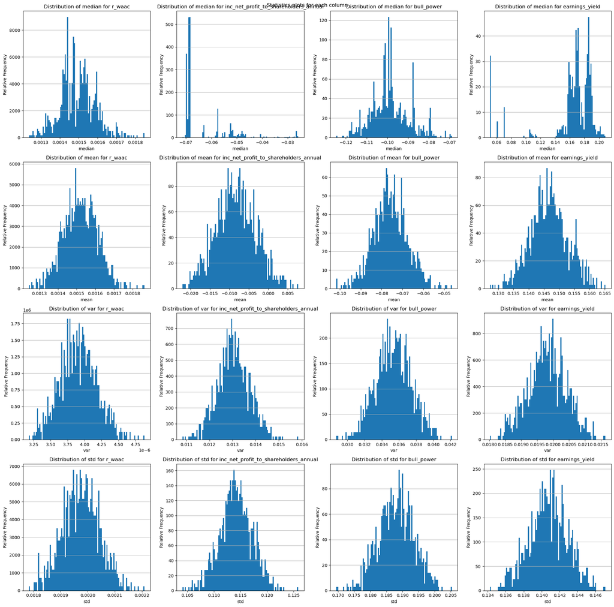

```
{'r_waac':       median      mean       var       std
 0   0.001505  0.001547  0.000004  0.001914
 0   0.001477  0.001411  0.000004  0.001912
 0   0.001451  0.001530  0.000004  0.002005
 0   0.001524  0.001430  0.000004  0.002023
 0   0.001698  0.001626  0.000004  0.001987
 ..       ...       ...       ...       ...
 0   0.001531  0.001508  0.000003  0.001866
 0   0.001497  0.001523  0.000004  0.002010
 0   0.001285  0.001283  0.000004  0.001939
 0   0.001424  0.001505  0.000003  0.001862
 0   0.001441  0.001593  0.000004  0.002002

 [1000 rows x 4 columns],
 'inc_net_profit_to_shareholders_annual':       median      mean       var       std
```

[output cut: 41 more lines]

```python
import warnings

warnings.filterwarnings("ignore")

random.seed(mol.random_state)

sampled_columns = random.sample(mol.industry_factors_df.columns.tolist(), k=3)
displayed_df = pd.concat([mol.industry_r_waac_df, mol.industry_factors_df[sampled_columns]], axis=1)

dcf.bootstrapping(
    sample=displayed_df,
    sample_frac=0.5,
    samples_count=1000,
    stats=['median', 'mean', 'var', 'std'],
    plot=True
)
```

As can be seen, r_waac and bull_power is highly normalized while others resemble noise.

#### 4.2 Heatmap for correlation

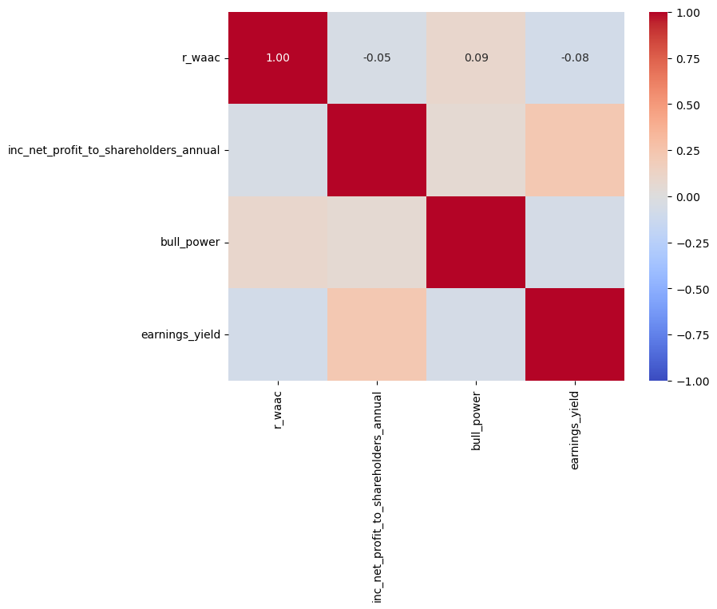

```python
correlation_matrix = displayed_df.corr()

plt.figure(figsize=(8, 6))

sns.heatmap(
    correlation_matrix,
    annot=True,
    cmap='coolwarm',
    fmt='.2f',
    vmin=-1,
    vmax=1,
    center=0
)
```

Note that 3 factors are weakly corrrelated:

- `'r_waac'` and `'bull_power'`: Positively correlated.
- `'r_waac'` and `'earnings_yield'`: Negatively correlated.
- `'bull_power'` and `'earnings_yield'`: Negatively correlated. \

while

#### 4.3 Time series and Moving average

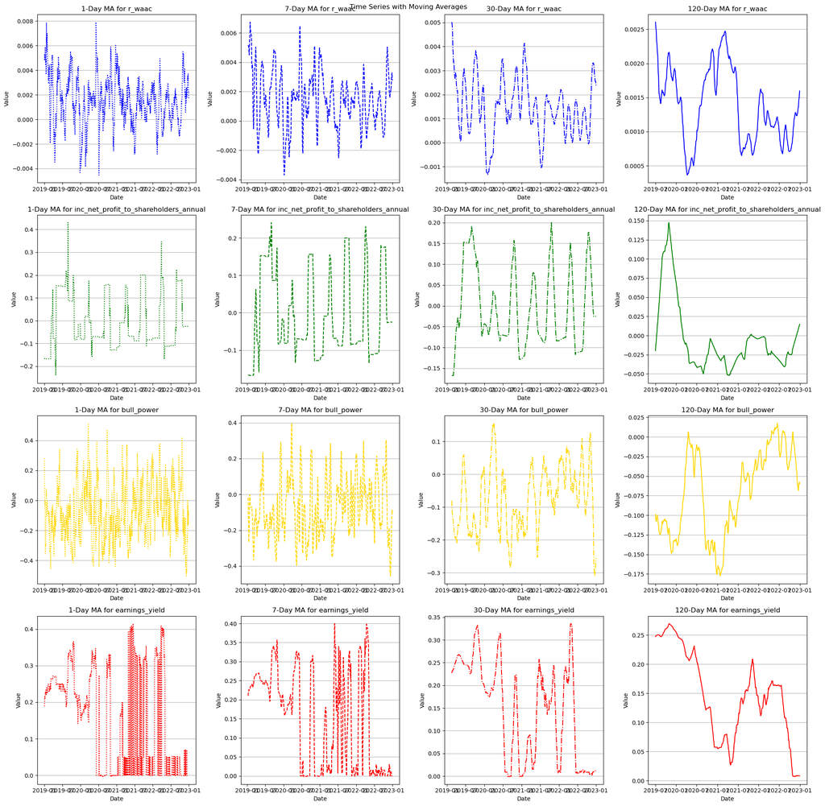

```python
windows = (1, 7, 30, 120)
num_row = len(windows)
num_cols = len(displayed_df.columns)

fig, axes = plt.subplots(
    nrows=num_row,
    ncols=num_cols,
    figsize=(5 * num_cols, 5 * num_row),
    squeeze=False
)

fig.suptitle('Time Series with Moving Averages')
for j, window, linestyle in zip(
        range(num_row),
        (1, 7, 30, 120),
        (':', '--', '-.', '-')
):
    ma_df = pd.DataFrame()
    for i, col, color in zip(
        range(num_cols),
        displayed_df.columns,
        ('blue', 'green', 'gold', 'red')
    ):
        ma_df['MA_' + str(window)] = displayed_df[col].rolling(window=window).mean()

        axes[i ,j].plot(mol.index, ma_df['MA_' + str(window)], color=color, linestyle=linestyle)
        axes[i, j].set_title(f'{window}-Day MA for {col}')
        axes[i, j].set_xlabel('Date')
        axes[i, j].set_ylabel('Value')
        axes[i, j].grid(axis='y')

    ma_df.index = mol.index

plt.tight_layout()
plt.show()
```

The observations about 120-Day MA are that:

while

- `'inc_net_profit_to_shareholders_annual'` has unique pattern.

## 3. Propoesed Method

### **Steps of the Method**

0. **Risk Classification**:  
   Distribute all indicators into 3 risk categories (Done in 3.2):
   - Default Risk
   - Liquidity Risk
   - Market Risk
1. **Data Preparation**:  
   Prepare the feature matrix `X` (a `DataFrame`) and the target variable `y` (a `Series`). Here, `X` contains all feature columns, and `y` is the target column, `r_waac`.
2. **Double Machine Learning** I use the **Double Machine Learning** to estimate the **causal effect** from a given risk type factors to the $r_{waac}^*$. Besides that, during this causal inference, the **causal effects** from other risk type factors to the $r_{waac}^*$ are removed, so that we can estimate the pure causal effects **only from** the risk we are interested in, without any confound effects from other risk factors.

The following is the introduction to the **Double Machine Learning**:

In the discussion below, we assume that we observe independent and identically distributed samples

$$ \{W_i=(Y_i, D_i, X_i): i=1,2,\dots,N\} $$

where

- $Y_i$ is the outcome,
- $D_i$ is the treatment (or policy) variable, and
- $X_i$ is a covariate vector that may confound the effect of $D$ on $Y$.

A popular model to capture potential confounding is the partially linear model

$$ \begin{aligned} Y &= D \theta_0 + g_0(X) + U,\quad \mathbb{E}[U | X,D]=0,\\[1mm] D &= m_0(X) + V,\quad\quad\; \mathbb{E}[V | X]=0, \end{aligned} $$

where

- $\theta_0$ is the causal parameter of interest,
- $g_0(X)$ is an unknown function capturing the “direct” effect of the covariates on $Y$,
- $m_0(X)=\mathbb{E}[D| X]$ is the “propensity function” (or the regression function for $D$), and
- $U$ and $V$ are error terms satisfying the stated conditional moment restrictions.

Because both $g_0(X)$ and $m_0(X)$ may be high–dimensional or very complex, we typically estimate them using flexible machine–learning methods. However, when these nuisance functions are estimated at slower rates, a naive plug–in estimator for $\theta_0$ would be plagued by bias. The DML strategy overcomes this by constructing a score function that is “orthogonal” (or “locally insensitive”) to small perturbations of the nuisance parameters.

### 1. The Orthogonal Moment (Score) Function

A common choice of the orthogonal score for the partially linear model is

$$ \psi(W; \theta, \eta) = \bigl[ Y - g(X) - \theta \bigl(D - m(X)\bigr) \bigr] (D - m(X)), $$

with the nuisance parameter defined as

$$ \eta = (g, m). $$

The “true” nuisance functions are simply

$$ \eta_0 =\bigl(g_0, m_0\bigr). $$

#### Validity of the Moment Condition

Under the model, let’s verify that the moment condition

$$ \mathbb{E}\bigl[\psi(W;\theta_0,\eta_0)\bigr]=0 $$

indeed holds. Substitute the true functions and the model into the score:

1. First, note that from the outcome equation

   $$ Y = D \theta_0+g_0(X)+ U, $$

   we have

   $$ Y - g_0(X) - \theta_0 (D-m_0(X)) = D \theta_0 + g_0(X) + U - g_0(X) - \theta_0 D + \theta_0 m_0(X) = U. $$
2. Hence, the moment becomes

   $$ \mathbb{E}\Bigl[\psi(W;\theta_0,\eta_0)\Bigr] = \mathbb{E}\Bigl[ U (D-m_0(X))\Bigr]. $$
3. Since by assumption $\mathbb{E}[U|X,D]=0$ and $D-m_0(X)$ is a function of $X$ (with mean zero given $X$), it follows that

   $$ \mathbb{E}\Bigl[ U (D-m_0(X))\Bigr]= \mathbb{E}\Bigl[\mathbb{E}\bigl[ U (D-m_0(X))| X\bigr]\Bigr]=0. $$

Thus, the true parameter $\theta_0$ satisfies

$$ \mathbb{E}\bigl[\psi(W;\theta_0,\eta_0)\bigr]=0. $$

### 2. Neyman Orthogonality

The key desirable property is that the score $\mathbb{E}\bigl[\psi(W;\theta_0,\eta_0)\bigr]$ is *Neyman orthogonal* (or doubly robust) with respect to the nuisance parameters. In our case, this means that the first–order differentiation of the population moment $\mathbb{E}\bigl[\psi(W;\theta_0,\eta_0)\bigr]$ with respect to $\eta$ vanishes at the true value $\eta_0$. Formally, for any perturbation $\eta-\eta_0$ in a specified set $T$,

$$ \left.\partial_\eta \mathbb{E}\bigl[\psi(W;\theta_0,\eta)\bigr]\right|_{\eta=\eta_0} (\eta-\eta_0) = 0. $$

What this implies in practice is that even if we substitute an estimate $\hat{\eta}$ for $\eta_0$ (and $\hat{\eta}$ is not super–accurate), its first–order error does not affect the moment condition—and hence the asymptotic distribution of the estimator of $\theta_0$.

### 3. The DML Estimator Using Sample Splitting (Cross–Fitting)

To further protect against overfitting and to make the estimation error in the nuisance parameters “orthogonal” to the estimation of $\theta_0$, we use sample splitting (or cross–fitting). The basic steps are as follows:

#### Step 3.1. Split the Data

Divide the full sample into $K$ folds. For simplicity, assume that $N$ is divisible by $K$, which equals $n$. Denote the folds by $I_1, I_2, \dots, I_K$ and therefore $|I_k| = n$. Let the complement of the $k$th fold be

$$ I^c_k = \{1,2,\dots,N\} \setminus I_k. $$

#### Step 3.2. Estimate the Nuisance Parameters

For each fold $k$, use the auxiliary sample $I^c_k$ to estimate the nuisance parameter $\eta_0$ by some machine–learning method. Denote the estimate by

$$ \hat{\eta}_{0,k} = \hat{\eta}_0\bigl((W_i)_{i\in I^c_k}\bigr) = (\hat{g}_{0, k}, \hat{m}_{0, k}). $$

#### Step 3.3. Solve the Moment Equation on the Main Sample

For each $k$, find $\tilde{\theta}_{0,k}$ that (approximately) solves the sample moment condition using the data in the $k$th fold:

$$ \frac{1}{n}\sum_{i\in I_k} \psi\Bigl(W_i; \tilde{\theta}_{0,k}, \hat{\eta}_{0,k}\Bigr) = 0. $$

Because the nuisance estimates $\hat{\eta}_{0,k}$ are obtained using data that are independent of those used in the moment condition, the contamination due to estimating $\eta_0$ is mitigated.

Then, average the fold-specific estimates:

$$ \tilde{\theta}_0 = \frac{1}{K}\sum_{k=1}^K \tilde{\theta}_{0,k}. $$

Another approach is to pool the moment equations from all folds and solve the $\tilde{\theta}_0$:

$$ \frac{1}{K}\sum_{k=1}^K \frac{1}{n}\sum_{i\in I_k} \psi\Bigl(W_i; \tilde{\theta}_0, \hat{\eta}_{0,k}\Bigr)=\frac{1}{N}\sum_{i=1}^N \psi(W_i; \tilde{\theta}_0, \hat{\eta}_{0,k})=0. $$

Both procedures are shown to be first–order equivalent.

### 4. Asymptotic Linearization and Inference

#### Step 4.1. Taylor Expansion of the Moment Equation

Focus on one fold $k$. Define the empirical moment function $\mathbb{\hat{E}}_n$ on $I_k$ as

$$ \mathbb{\hat{E}}_{n,k}\bigl[f(W)\bigr]=\frac{1}{n} \sum_{i\in I_k} f(W_i), $$

where $n=n=N/K$. Now, by a first–order Taylor expansion around $(\theta_0, \eta_0)$, we write

$$ \begin{aligned} 0 &= \mathbb{\hat{E}}_{n,k}\bigl[\psi(W; \tilde{\theta}_{0,k}, \hat{\eta}_{0,k}) \bigr] \\ &= \mathbb{\hat{E}}_{n,k}\bigl[\psi(W; \theta_0, \eta_0) \bigr] + J_0 (\tilde{\theta}_{0,k} - \theta_0) \\ &\quad \quad + \underbrace{\partial_\eta \mathbb{E}_P\bigl[\psi(W; \theta_0, \eta_0)\bigr](\hat{\eta}_{0,k}-\eta_0)}_{=0\text{ by Neyman orthogonality}} + R_{n,k}, \end{aligned} $$

where

$$ J_0 = \left. \partial_\theta \mathbb{E}_P\bigl[\psi(W; \theta, \eta_0)\bigr]\right|_{\theta=\theta_0}, $$

and $R_{n,k}$ is a remainder term that is negligible (i.e. $o_P(n^{-1/2})$) under regularity conditions.

Since the derivative in the nuisance direction vanishes (by Neyman orthogonality), we obtain

$$ \tilde{\theta}_{0,k} - \theta_0 = -J_0^{-1} \Biggl\{ \mathbb{\hat{E}}_{n,k}\bigl[ \psi(W; \theta_0, \eta_0) \bigr] + R_{n,k} \Biggr\}. $$

#### Step 4.2. Aggregation Over Folds

Averaging (or pooling) the fold–specific estimators we have

$$ \tilde{\theta}_0 - \theta_0 = -J_0^{-1} \left(\frac{1}{K}\sum_{k=1}^K \mathbb{\hat{E}}_{n,k}\bigl[\psi(W; \theta_0, \eta_0)\bigr]\right)+ o_P(N^{-1/2}). $$

Since the $K$ folds together cover the full sample, we can write

$$ \begin{align*} &\frac{1}{K}\sum_{k=1}^K \mathbb{\hat{E}}_{n,k}\bigl[\psi(W; \theta_0, \eta_0)\bigr] \\ = &\frac{1}{K}\sum_{k=1}^K \frac{1}{n} \sum_{i \in I_k} \bigl[\psi(W_i; \theta_0, \eta_0)\bigr] \\ = &\frac{1}{N}\sum_{i=1}^N \psi(W_i; \theta_0,\eta_0). \end{align*} $$

Thus, multiplying by $\sqrt{N}$ yields the asymptotically linear expansion

$$ \sqrt{N}(\tilde{\theta}_0 - \theta_0) = -J_0^{-1} \frac{1}{\sqrt{N}}\sum_{i=1}^N \psi(W_i;\theta_0,\eta_0) + o_P(1). $$

#### Step 4.3. Asymptotic Normality

By the classical central limit theorem (CLT), we have

$$ \frac{1}{\sqrt{N}}\sum_{i=1}^N \psi(W_i;\theta_0,\eta_0) \stackrel{d}{\longrightarrow} N(0, \Omega), $$

where

$$ \Omega = \mathbb{E}\Bigl[\psi(W;\theta_0,\eta_0)\psi(W;\theta_0,\eta_0)^\top\Bigr]. $$

Therefore, the DML estimator is asymptotically linear and normal:

$$ \sqrt{N}(\tilde{\theta}_0-\theta_0)\stackrel{d}{\longrightarrow} N\Bigl(0, J_0^{-1}\Omega (J_0^{-1})^\top \Bigr). $$

### 5. Project Setting

In our specific context, note that since the score is linear in $\theta$ the derivative is easy to calculate. In fact, observe that

$$ \psi(W;\theta, \eta) = (Y-g(X)) (D-m(X)) - \theta (D-m(X))^2. $$

To solve the equations in session 3.3:

$$ \frac{1}{n}\sum_{i\in I_k} \psi\Bigl(W_i; \tilde{\theta}_{0,k}, \hat{\eta}_{0,k}\Bigr) = 0 $$

or

$$ \frac{1}{N}\sum_{i=1}^N \psi(W_i; \tilde{\theta}_0, \hat{\eta}_{0,k})=0. $$

Let’s substitute the function form into the sample moment equation. For each observation $i \in I_k$, we have

$$ \psi\Bigl(W_i; \tilde{\theta}_{0,k}, \hat{\eta}_{0,k}\Bigr) = \Bigl(Y_i - \hat{g}_{0, k}(X_i)\Bigr)\,\Bigl(D_i - \hat{m}_{0, k}(X_i)\Bigr) - \tilde{\theta}_{0,k}\,\Bigl(D_i - \hat{m}_{0, k}(X_i)\Bigr)^2. $$

Thus, the sample moment equation becomes

$$ \frac{1}{n}\sum_{i\in I_k} \Bigl[\Bigl(Y_i - \hat{g}_{0, k}(X_i)\Bigr)\,\Bigl(D_i - \hat{m}_{0, k}(X_i)\Bigr) - \tilde{\theta}_{0,k}\,\Bigl(D_i - \hat{m}_{0, k}(X_i)\Bigr)^2\Bigr]= 0. $$

#### Step 5.1 Rearrangement

Multiply both sides of the equation by $n$:

$$ \sum_{i\in I_k}\Bigl[\Bigl(Y_i - \hat{g}_{0, k}(X_i)\Bigr)(D_i - \hat{m}_{0, k}(X_i)) - \tilde{\theta}_{0,k}\,(D_i - \hat{m}_{0, k}(X_i))^2\Bigr] = 0. $$

#### Step 5.2 Isolate the $\theta$–Term

Bring the term involving $\theta$ to the right‐hand side:

$$ \sum_{i\in I_k} \Bigl(Y_i - \hat{g}_{0, k}(X_i)\Bigr)(D_i - \hat{m}_{0, k}(X_i)) = \tilde{\theta}_{0,k}\,\sum_{i\in I_k} \Bigl(D_i - \hat{m}_{0, k}(X_i)\Bigr)^2. $$

#### Step 5.3 Solve for $\tilde{\theta}_{0,k}$

Divide both sides by the term $\sum_{i\in I_k}(D_i - \hat{m}_{0, k}(X_i))^2$:

$$ \tilde{\theta}_{0,k} = \frac{\displaystyle \sum_{i\in I_k} \Bigl(Y_i - \hat{g}_{0, k}(X_i)\Bigr)(D_i - \hat{m}_{0, k}(X_i))}{\displaystyle \sum_{i\in I_k} \Bigl(D_i - \hat{m}_{0, k}(X_i)\Bigr)^2}. $$

This formula provides the “debiased” estimator for $\theta_0$ on the fold $I_k$.

Define $\tilde{Y}_i := Y_i - \hat{g}_{0, k}(X_i)$ and $\tilde{D}_i := D_i - \hat{m}_{0, k}(X_i)$. Note that we obtain $\tilde{Y}_i$ or $\tilde{D}_i$ by using double machine learning models $\hat{g}_{0, k}$ or $\hat{m}_{0, k}$ and data $X_i$ to fit $Y_i$ or $D_i$ respectively. During this process, using as strong models as possible is encouraged, in order to make the closest approximations:

$$ \hat{g}_{0, k}(X_i) \approx \mathbb{E}_k(Y_i | X_i) = m_0(X_i) \theta_0 + g_0(X_i) + \mathbb{E}_k(U_i | X_i) \leftrightarrow \tilde{Y}_i \approx V_i \theta_0 + U_i - \mathbb{E}_k(U_i | X_i), $$

or

$$ \hat{m}_{0, k}(X_i) \approx \mathbb{E}_k(D_i | X_i) = m_0(X_i) \leftrightarrow \tilde{D}_i \approx V_i $$

Therefore, we have $$ \mathbb{E}_k(\tilde{Y}_i | \tilde{D}_i) = \tilde{D}_i \theta_0 + \mathbb{E}_k(U_i | \tilde{D}_i) $$

and

$$ \mathbb{E}_k(\tilde{Y}_i | \tilde{D}_i, X_i) = \tilde{D}_i \theta_0 $$

.

where $\mathbb{E}_k(\mathbb{E}_k(U_i | X_i) | \tilde{D}_i) = \mathbb{E}_k(U_i | V_i, X_i) = \mathbb{E}_k(U_i | D_i, X_i) = 0$.

Another approximation is also to be ensured in the tyler expansion by the using a strong model:

$$ \hat{\eta}_{0, k} \approx \eta_0. $$

We have the following results:

$$ \begin{aligned} \tilde{\theta}_{0,k} &= \frac{\displaystyle \frac{1}{n} \sum_{i\in I_k} \Bigl(Y_i - \hat{g}_{0, k}(X_i)\Bigr)(D_i - \hat{m}_{0, k}(X_i))}{\displaystyle \frac{1}{n} \sum_{i\in I_k} \Bigl(D_i - \hat{m}_{0, k}(X_i)\Bigr)^2} \\ &= \frac{\mathbb{\hat{E}}_{n, k}(\tilde{Y}_i \tilde{D}_i)}{\mathbb{\hat{E}}_{n, k}(\tilde{D}_i^2)} \\ &= \frac{\mathbb{\hat{E}}_{n, k}(\tilde{Y}_i \tilde{D}_i) - \mathbb{\hat{E}}_{n, k}(\tilde{Y}_i) \mathbb{\hat{E}}_{n, k}(\tilde{D}_i)}{\mathbb{\hat{E}}_{n, k}(\tilde{D}_i^2) - \mathbb{\hat{E}}_{n, k}(\tilde{D}_i)^2} \\ &= \frac{\widehat{\text{Cov}}_{n, k}(\tilde{Y}_i, \tilde{D}_i)}{\widehat{\text{Var}}_{n, k}(\tilde{D}_i)} \\ &= \hat{\beta}_{0, k} \end{aligned} $$

where $\mathbb{\hat{E}}_{n, k}(\tilde{D}_i) = 0$ and $\hat{\beta}_{0, k}$ is the coefficient of the linear regression $\tilde{Y}_i = \hat{\beta}_{0, k} \tilde{D}_i + \hat{\epsilon}_i$.

Therefore, we again fit the $\tilde{Y}_i$ using linear regression and data $\tilde{D}_i$ in the $k$th-fold to estimate the $\hat{\beta}_{0, k} = \tilde{\theta}_{0,k}$.

Then, average the fold-specific estimates:

$$ \tilde{\theta}_0 = \frac{1}{K}\sum_{k=1}^K \tilde{\theta}_{0,k}. $$

Similarly, if one aggregates over the entire sample (or pools the estimating equations), one obtains

$$ \tilde{\theta}_{0} = \hat{\beta}_0. $$

Furthermore,

$$ J_0 = - \mathbb{E}\Bigl[(D-m_0(X))^2 \Bigr]. $$

Moreover, after substituting the model $Y = D\theta_0 + g_0(X)+U$ and using our earlier derivation, one can show that

$$ \Omega=\mathbb{E}\Bigl[\psi(W;\theta_0,\eta_0)^2\Bigr]= \mathbb{E}\Bigl[U^2 (D-m_0(X))^2 \Bigr]. $$

where we fit the $\tilde{Y}$ using linear regression and data $\tilde{D}$ in the whole dataset to estimate the $\hat{\beta}_0 = \tilde{\theta}_0$.

In our project, here are the variables settings:

- $\mathcal{C}$: The risk type we are interested in.
- We pick each risk type of factors $\mathcal{C}$ from $\{ \mathcal{C}_{\text{DR}}, \mathcal{C}_{\text{LR}}, \mathcal{C}_{\text{MR}} \}$ to estimate their causal effect $\theta_0$ to $r_{waac}$ iteratively.
- $D = [\textbf{BII} | \textbf{BII} \in \mathcal{C}]^\top$: The confounder factors matrix with the risk type we are interested in.
- $X = [\textbf{BII} | \textbf{BII} \not\in \mathcal{C}]^\top$: The confounder factors matrix out of the risk type we are interested in.
- $y = r_{waac}$: The dependent variable we are interested in.
- $\theta_0$: Causal inference goal in our project.